# Lab 3 - Exploring Many Categorical Variables with R

### Data set: Airline arrivals

We are now going to compare all the techniques seen so far on a new dataset.

Download data: airlineArrival

The `airlineArrival` data contains 11000 observations of 3 categorical variables: * `Airport` - a factor with levels `LosAngeles`, `Phoenix`, `SanDiego`, `SanFrancisco`, `Seattle` * `Result` - a factor with levels `Delayed`,`OnTime` * `Airline` - a factor with levels `Alaska`, `AmericaWest`

### **Task 3a**

- Create a grouped barplot of the counts of delayed flights versus ontime flights for both levels of the `Airline` variable.
- Create a stacked barplot of the same data above
- Is there much difference in the amount of delayed flights between the two airlines? Which plot is better to assess this?

**Click for solution**

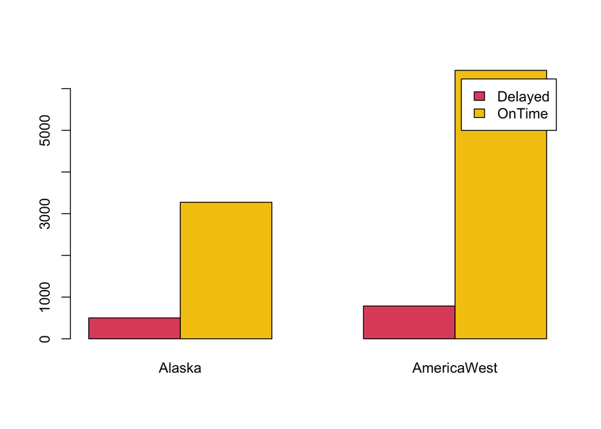

```r
tab <- xtabs(~Result+Airline,data=airlineArrival)

# Grouped barplot
barplot(tab, beside=TRUE, legend=rownames(tab), col=c(2,7))
```

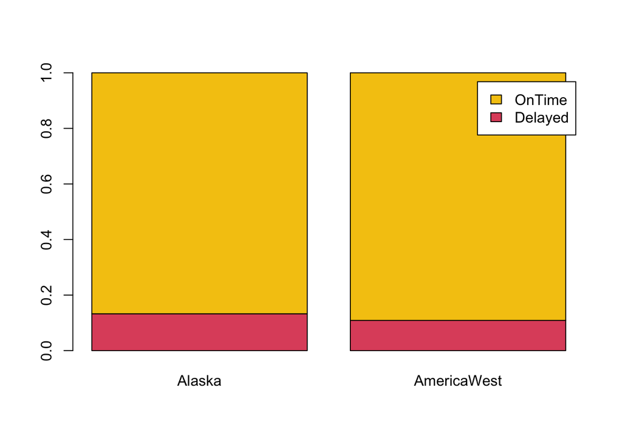

```r
# Stacked barplot
barplot(prop.table(tab, margin=2), beside=FALSE, legend=rownames(tab), col=c(2,7))
```

In the second plot we can see much better that the proportion is roughly the same. In the first plot, it is easier to see the actual counts of delayed and on time flights.

### **Task 3b**

- Produce grouped and stacked barcharts of counts of `Airport` against `Result`. What is the response variable here?
  - Which airports look best for flights being on time? Which look worst?

**Click for solution**

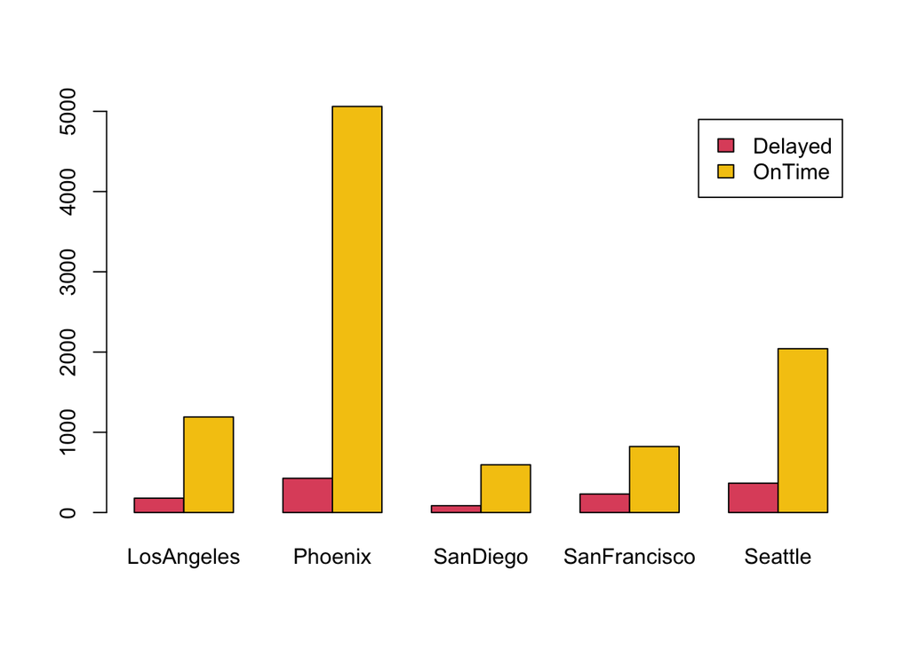

```r
tab <- xtabs(~Result+Airport,data=airlineArrival)

# Grouped barplot
barplot(tab, beside=TRUE, legend=rownames(tab), col=c(2,7))
```

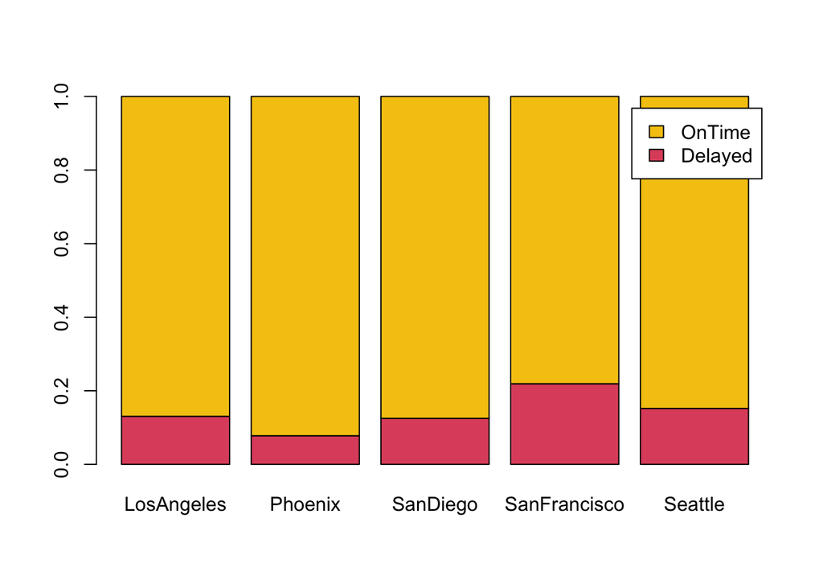

```r
# Stacked barplot
barplot(prop.table(tab, margin=2), beside=FALSE, legend=rownames(tab), col=c(2,7))
```

Once again, stacked plots are more useful: `Result` is clearly the response variable here and hence we need to produce five different bars.

San Francisco is the worse airport and Phoenix the best in terms of flights being on time.

### **Task 3c**

- Now look at whether both `Airport` and `Airline` are associated with delays by producing a mosaicplot and a doubledecker plot of all three variables.
- What do you find? Try turning on `shade=TRUE`.
- In which plot are the associations most pronounced?

**Click for solution**

Here is the mosaicplot

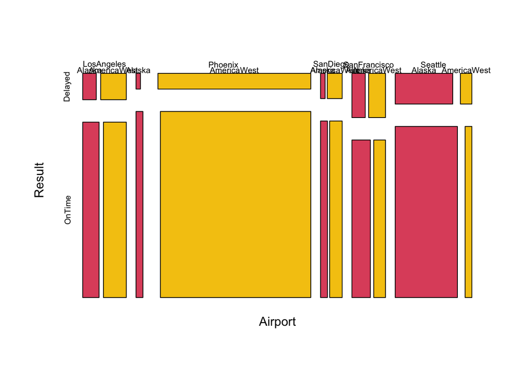

```r
mosaicplot(~Airport+Result+Airline, data=airlineArrival,col=c(2,7),main='')
```

Here is the doubledecker plot

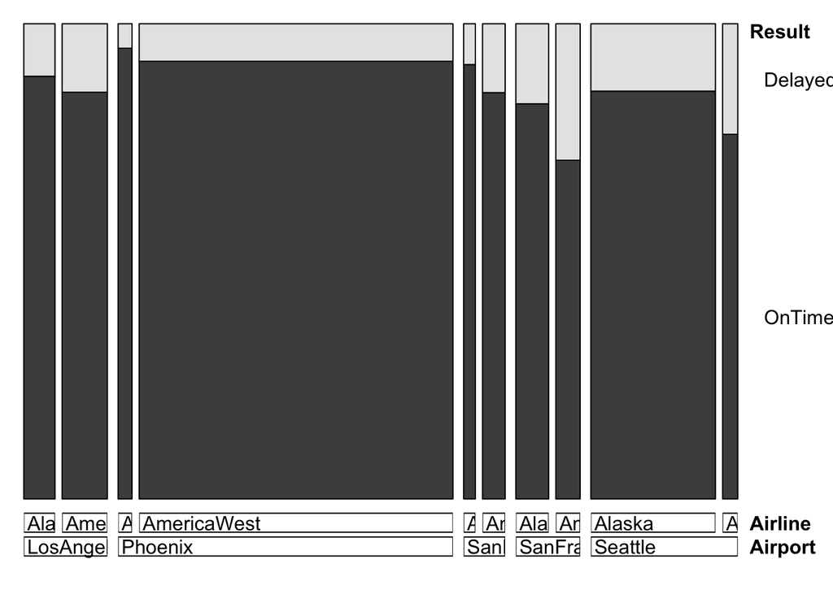

```r
doubledecker(xtabs(~Airport+Airline+Result, data=airlineArrival))
```

The doubledecker is better at showing that Alaska airlines is doing a good job getting flights from Phoenix to be ontime.

The shaded mosaicplot confirms this finding, but gives much more information about unusual associations:

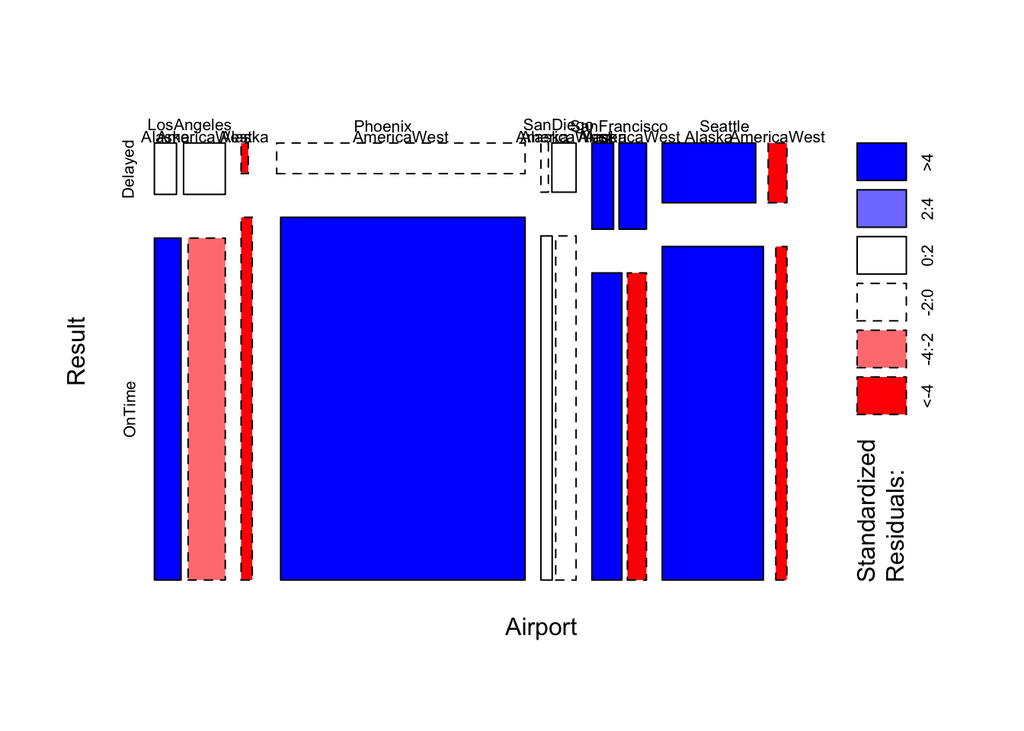

```r
mosaicplot(~Airport+Result+Airline, data=airlineArrival, col=c(2,7), shade=TRUE, main=' ')
```